# S&P500 Stocks Data Analysis

#### Model performance measures

Model 6 - the custom model performs pretty well than muliple linear model. ( model 5)

We will split the data to calculate the performance measures. We will use a 70-30 split.

```r
#model 5 and model6 looks better
# we will choose them for training and testing

set.seed(123)
train_idx <- sample(nrow(d), .70*nrow(d))

d_train <- d[train_idx,]
d_test <- d[-train_idx,]
```

```r
train_mod1 <- lm(eps ~ ebitda+ marketcap + price+  divyield, d_train)
summary(train_mod1)
train_mod2 <- lm(eps ~ log(price) + ebitda +  log(marketcap) +  divyield, d_train)
summary(train_mod2)
```

```
Call:
lm(formula = eps ~ ebitda + marketcap + price + divyield, data = d_train)

Residuals:
    Min      1Q  Median      3Q     Max
-30.859  -1.236  -0.203   1.301  35.449

Coefficients:
              Estimate Std. Error t value Pr(>|t|)
(Intercept)  7.232e-01  4.907e-01   1.474    0.141
ebitda       3.498e-10  6.773e-11   5.165 4.05e-07 ***
marketcap   -3.054e-11  5.923e-12  -5.156 4.23e-07 ***
price        2.753e-02  2.043e-03  13.473  < 2e-16 ***
divyield     2.429e-01  1.772e-01   1.371    0.171
---
Signif. codes:  0 '***' 0.001 '**' 0.01 '*' 0.05 '.' 0.1 ' ' 1

Residual standard error: 4.499 on 348 degrees of freedom
Multiple R-squared:  0.3604,	Adjusted R-squared:  0.353
F-statistic: 49.01 on 4 and 348 DF,  p-value: < 2.2e-16
```

```
Call:
lm(formula = eps ~ log(price) + ebitda + log(marketcap) + divyield,
    data = d_train)

Residuals:
    Min      1Q  Median      3Q     Max
-31.790  -1.560   0.033   1.393  31.747

Coefficients:
                 Estimate Std. Error t value Pr(>|t|)
(Intercept)    -1.218e+01  7.815e+00  -1.559   0.1200
log(price)      4.254e+00  3.710e-01  11.466   <2e-16 ***
ebitda          5.958e-11  5.121e-11   1.164   0.2454
log(marketcap) -1.383e-01  3.505e-01  -0.395   0.6933
divyield        4.126e-01  1.850e-01   2.231   0.0263 *
---
Signif. codes:  0 '***' 0.001 '**' 0.01 '*' 0.05 '.' 0.1 ' ' 1

Residual standard error: 4.632 on 348 degrees of freedom
Multiple R-squared:  0.3219,	Adjusted R-squared:  0.3141
F-statistic: 41.29 on 4 and 348 DF,  p-value: < 2.2e-16
```

```r
#  predicting the response variable in testing dataset using the predictor variable in the same dataset(training dataset)

prd1 <- predict(train_mod1, d_test)
str(prd1)
prd2 <- predict(train_mod2, d_test)
str(prd2)
```

```
 Named num [1:152] 6.35 1.63 1.98 3.82 3.84 ...
 - attr(*, "names")= chr [1:152] "1" "3" "6" "8" ...
 Named num [1:152] 8.77 2.59 2.56 6.69 4.79 ...
 - attr(*, "names")= chr [1:152] "1" "3" "6" "8" ...
```

We will use a function to calcualte the actual model performance metrics.Mainly three particular error measures:

```r
calc_performance <- function(actual, pred) {
  rmse <- sqrt(mean((actual - pred)**2))
  mae <- mean(abs(actual - pred))
  rsq <- 1 - (sum((actual - pred)**2))/(sum((actual - mean(actual))**2))
  return(list(rmse = rmse, mae = mae, Rsquared = rsq))
  }
```

### Calculating model performance

```r
calc_performance(d_test$eps, prd1)

calc_performance(d_test$eps, prd2)
```

**$rmse**

4.63388981246886

**$mae**

2.75254313055801

**$Rsquared**

0.384045558959733

**$rmse**

4.61433260923435

**$mae**

2.6673807111221

**$Rsquared**

0.389233824558773

Observation: Both model performance are almost the same. But model 6 is better than model5  
i.e custom model is better than multiple linear regression model.

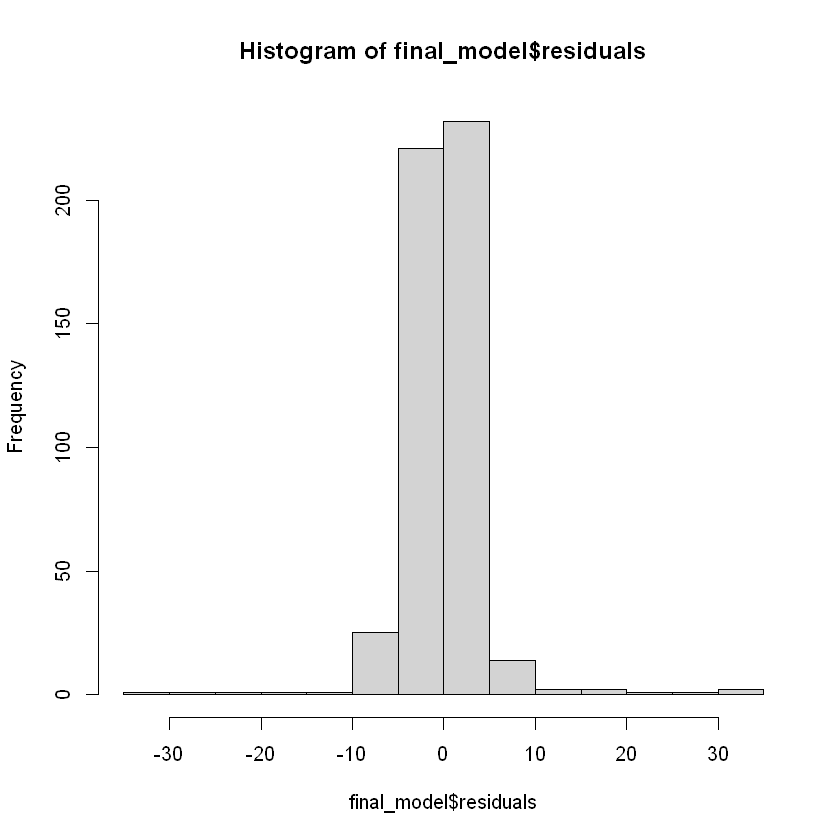

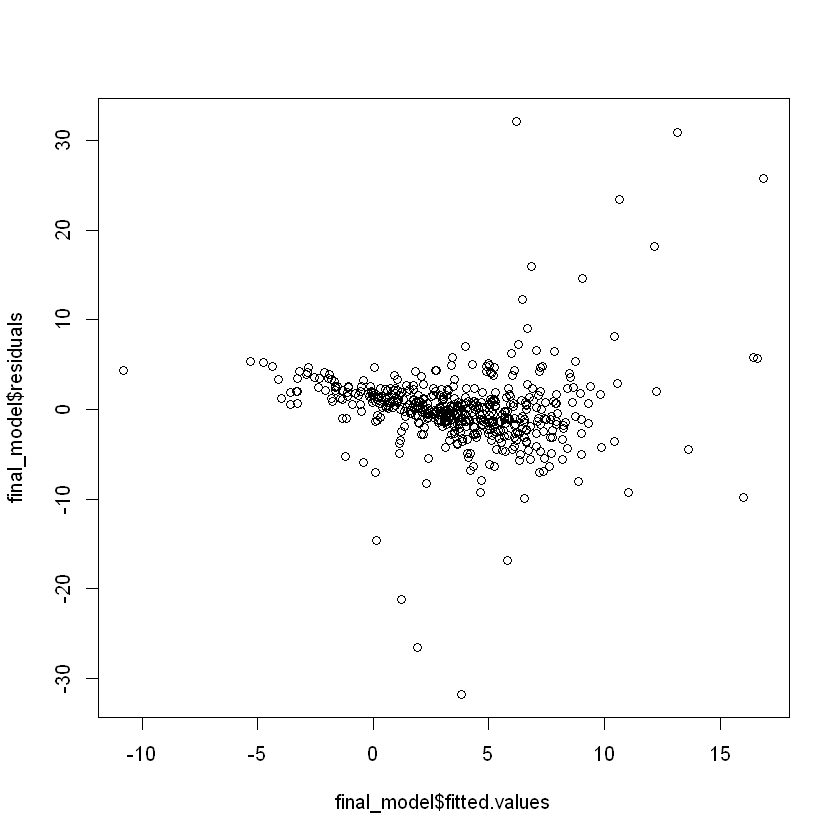

```r
#using the model 6...
final_model <- lm(eps ~ log(price) + ebitda +  log(marketcap) +  divyield, d)

hist(final_model$residuals)
plot(final_model$fitted.values, final_model$residuals)
```

The final_model looks pretty decent enough for the prediction of the response variable eps(Earnings per Share).

We will continue to use custom control parameters and create models.

## 7 . Models using custom control parameters from different package

Before jumping into different models, let us see the Univariate case and Multivariate case in Regression Anlysis.

**Regression Analyis**

Univariate case  
Typically we analyze the effect of one or more continuous explanatory variables on a single continuous response variable

Multivariate case  
We analyze the effect of one or more continuous explanatory variables on more than one continuous response variable.

Mulitple linear regression by least-squares method

If explanatory variables are highly correlated we use Partial least squares model.  
The mathematical model depicting Partial least squares model for Mulitple linear regression is,  
Y=XB+E  
Y-Response matrix (nm)  
X=Predictor matrix (np)  
B=Coefficicent matrix (pm)  
E=noise term (nm)  
where,

n-No. of observations  
m-No. of response variables  
p-No. of predictor continuous

### Caret package - Classification And Regression Training

We are using Caret package to build models using custom comtrol parameters.  
Caret package has several functions that attempt to streamline the model building and evaluation process, as well as feature selection and other techniques.

One of the primary tools in the package is the train function which can be used to  
a.Evaluate, using resampling, the effect of model tuning parameters on performance  
b.Choose the optimal model across these parameters  
c.Estimate model performance from a training set

We will use trainControl function present in caret package to define custom control parameters for regression models.

The parameters used for creating a custom control include, method, "repeatedcv".  
It is used to specify repeated K-fold cross-validation (and the argument repeats controls the number of repetitions).  
K is controlled by the 'number' argument and defaults to 10.

```r
# this is a usage of traincontrol function to define a control parameter
ctrl <- trainControl(method = "repeatedcv", repeats =10)
```

**We will first use pslr function and then compare the results of fit.plsr model and the final model we already chose**

plsr stands for Partial Least square model

```r
fit.plsr <- plsr(d$eps ~ d$ebitda+ d$marketcap + d$price +  d$divyield, dataset=d, ncomp=4,validation="CV" )
#summary of fit.plsr model
summary(fit.plsr)
```

```
Data: 	X dimension: 505 4
	Y dimension: 505 1
Fit method: kernelpls
Number of components considered: 4

VALIDATION: RMSEP
Cross-validated using 10 random segments.
       (Intercept)  1 comps  2 comps  3 comps  4 comps
CV           5.695    5.608    5.616    4.602    4.611
adjCV        5.695    5.606    5.614    4.594    4.602

TRAINING: % variance explained
       1 comps  2 comps  3 comps  4 comps
X       99.768  100.000    100.0   100.00
d$eps    3.772    4.002     38.5    38.68
```

```r
#comparing with final_model
summary(final_model)
```

```
Call:
lm(formula = eps ~ log(price) + ebitda + log(marketcap) + divyield,
    data = d)

Residuals:
    Min      1Q  Median      3Q     Max
-31.833  -1.496   0.019   1.561  32.149

Coefficients:
                 Estimate Std. Error t value Pr(>|t|)
(Intercept)    -7.088e+00  6.354e+00  -1.116  0.26513
log(price)      4.442e+00  3.058e-01  14.528  < 2e-16 ***
ebitda          1.064e-10  3.935e-11   2.704  0.00709 **
log(marketcap) -3.898e-01  2.848e-01  -1.369  0.17173
divyield        3.568e-01  1.432e-01   2.491  0.01307 *
---
Signif. codes:  0 '***' 0.001 '**' 0.01 '*' 0.05 '.' 0.1 ' ' 1

Residual standard error: 4.617 on 500 degrees of freedom
Multiple R-squared:  0.3465,	Adjusted R-squared:  0.3412
F-statistic: 66.26 on 4 and 500 DF,  p-value: < 2.2e-16
```

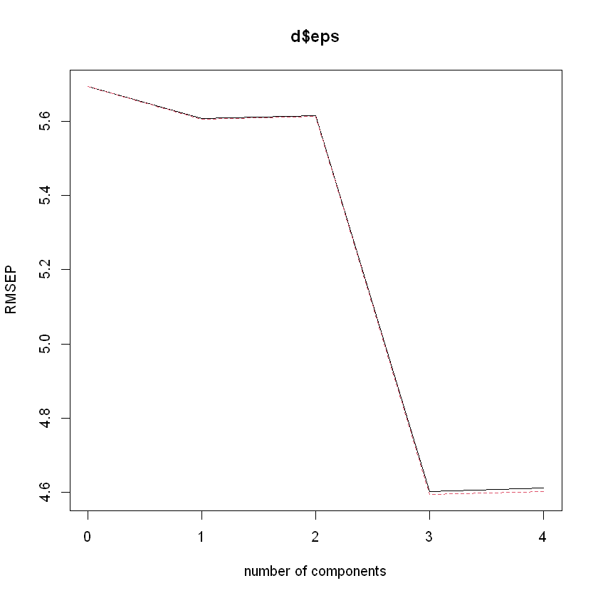

```r
plot(RMSEP(fit.plsr))
# with many components in play rmse reduces
```

```r
# training the fit pslr model
train_fit.plsr <- plsr(d_train$eps ~ d_train$ebitda + d_train$marketcap + d_train$price + d_train$divyield, dataset=d_train, ncomp=4,validation="CV" )
summary(train_fit.plsr)

pred.plsr <- predict(train_fit.plsr,d_test)
```

```
Data: 	X dimension: 353 4
	Y dimension: 353 1
Fit method: kernelpls
Number of components considered: 4

VALIDATION: RMSEP
Cross-validated using 10 random segments.
       (Intercept)  1 comps  2 comps  3 comps  4 comps
CV           5.601    5.581    5.587    4.692    4.705
adjCV        5.601    5.578    5.583    4.678    4.690

TRAINING: % variance explained
             1 comps  2 comps  3 comps  4 comps
X             99.752  100.000   100.00   100.00
d_train$eps    1.679    2.277    35.69    36.04
```

### Models comparison

```r
#comparing performance  of 2 models
calc_performance(d_test$eps, prd2)

calc_performance(d_test$eps, pred.plsr)


# rmse.plsr <- sqrt(mean((actual - pred)**2))
# rmse.fm <- sqrt(mean((actual - pred)**2))
# rmse.model5 <- sqrt(mean((actual - pred)**2))
```

**$rmse**

4.61433260923435

**$mae**

2.6673807111221

**$Rsquared**

0.389233824558773

**$rmse**

6.46604824892372

**$mae**

3.72396523662024

**$Rsquared**

-10.1410513567657

It is quite obvious that if the whole fit pslr model does not perform well than the final model, even the predicted model gives same type of result.  
RMSE values of fit.plsr model is greater than our final_model

### Plotting the above inferences graphically

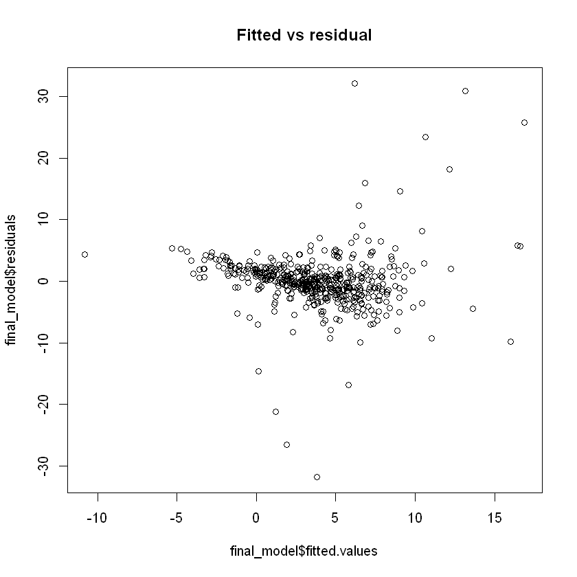

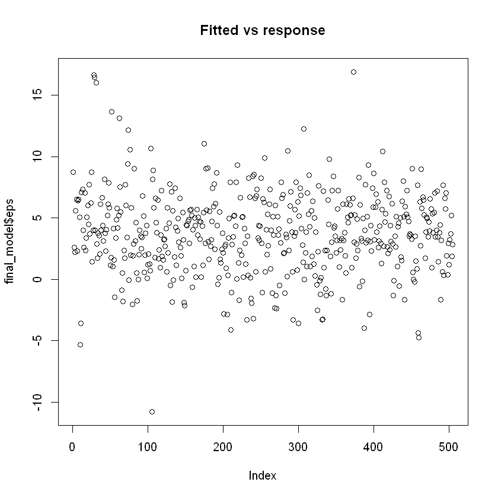

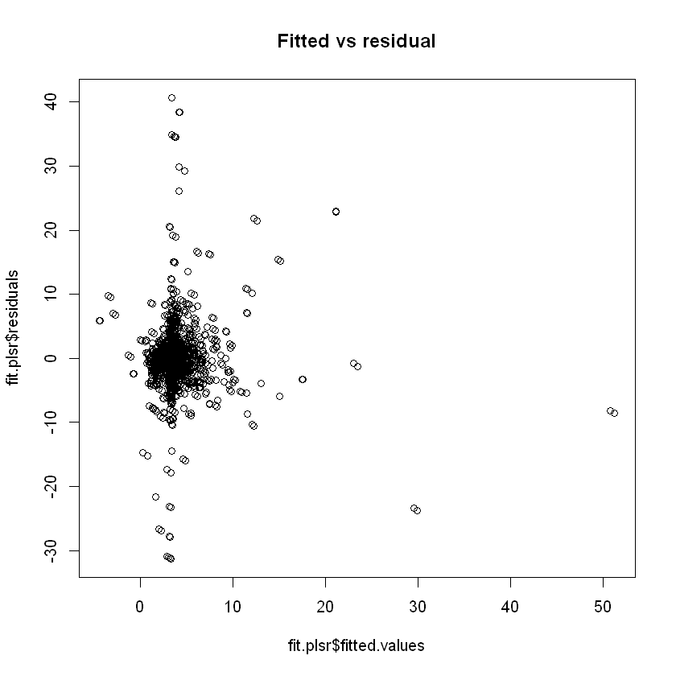

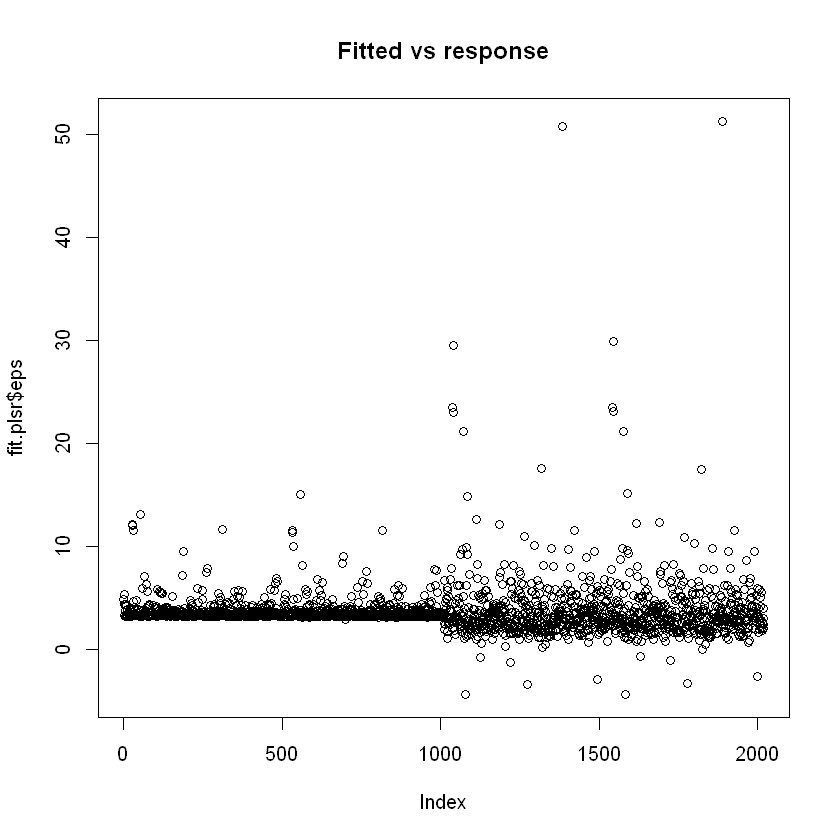

```r
#final model **************

# fitted vs residual
p01 <- plot(final_model$fitted.values, final_model$residuals ,main="Fitted vs residual")
# fitted vs response
p02 <- plot(final_model$fitted.values, final_model$eps ,main="Fitted vs response" )


#plsr model*************

# fitted vs residual
p03 <- plot(fit.plsr$fitted.values, fit.plsr$residuals ,main="Fitted vs residual")
# fitted vs response
p04 <- plot(fit.plsr$fitted.values, fit.plsr$eps ,main="Fitted vs response" )


#final model is way better than plsr model
```

### 7.1 . Linear Regression Model using custom control parameters

From the caret package we will use simpls method and custom control parameters.

```r
# running the above code again
# this is a usage of traincontrol function to define a control parameter
ctrl <- trainControl(method = "repeatedcv", repeats =10)
```

```r
# we will implement method 'simpls'

plsFit <- train(
  eps ~ .,
  data = d_train,
  method = "simpls",
  ## Center and scale the predictors for the training
  ## set and all future samples.
  preProc = c("center", "scale"),
  trControl = ctrl )


# final HTML will not have this code output(to shorten the length of document)
```

We will now look at the results and summary of plsfit model

A data.frame: 3 × 7

|  | ncomp <dbl> | RMSE <dbl> | Rsquared <dbl> | MAE <dbl> | RMSESD <dbl> | RsquaredSD <dbl> | MAESD <dbl> |
| --- | --- | --- | --- | --- | --- | --- | --- |
| 1 | 1 | 4.351334 | 0.3866656 | 2.455783 | 1.687303 | 0.2065329 | 0.5776595 |
| 2 | 2 | 4.437164 | 0.4191191 | 2.551590 | 1.676882 | 0.2178780 | 0.5766545 |
| 3 | 3 | 4.448898 | 0.4173027 | 2.567126 | 1.666857 | 0.2147089 | 0.5725033 |

```
Partial Least Squares

353 samples
 10 predictor

Pre-processing: centered (1025), scaled (1025)
Resampling: Cross-Validated (10 fold, repeated 10 times)
Summary of sample sizes: 317, 317, 317, 318, 317, 317, ...
Resampling results across tuning parameters:

  ncomp  RMSE      Rsquared   MAE
  1      4.351334  0.3866656  2.455783
  2      4.437164  0.4191191  2.551590
  3      4.448898  0.4173027  2.567126

RMSE was used to select the optimal model using the smallest value.
The final value used for the model was ncomp = 1.
```

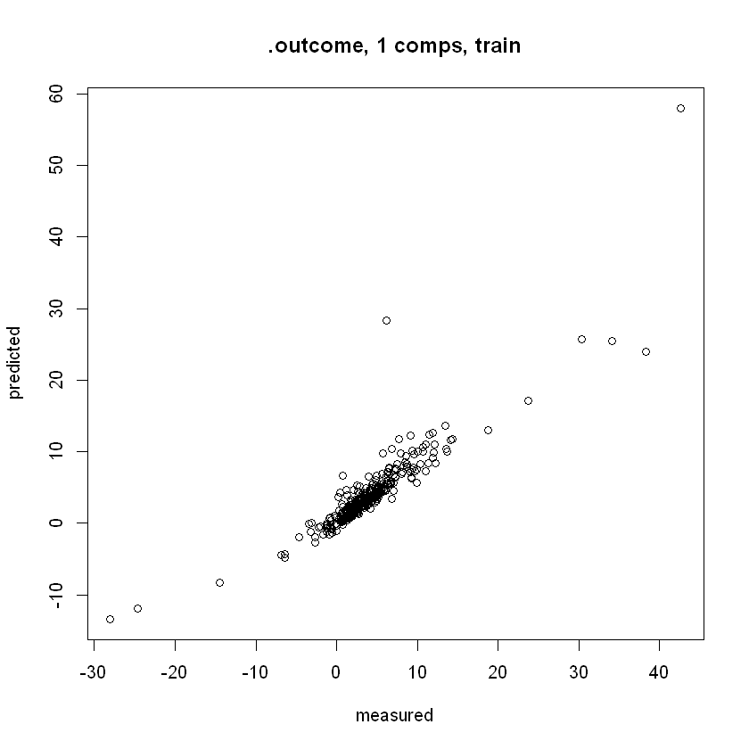

```r
plsFit$results
plsFit

plot(plsFit$finalModel, col = "black")
```

Now we will predict the response variable in our testing dataset using the predictor variable(s) in the same dataset for the plsfit model.

```r
pred.plsfit <- predict(plsFit,d_test)
```

### Comparing the predicted models

```r
calc_performance(d_test$eps, pred.plsfit)

calc_performance(d_test$eps, prd2)

calc_performance(d_test$eps, pred.plsr)
```

**$rmse**

4.40098189472819

**$mae**

2.4521858638619

**$Rsquared**

0.444407532176233

**$rmse**

4.61433260923435

**$mae**

2.6673807111221

**$Rsquared**

0.389233824558773

**$rmse**

6.46604824892372

**$mae**

3.72396523662024

**$Rsquared**

-10.1410513567657

This shows that pls fit model made by using custom control parameters is better than the final model  
RMSE of pls fit model - 4.40  
RMSE of final model - 4.61

Plotting the histograms for these models

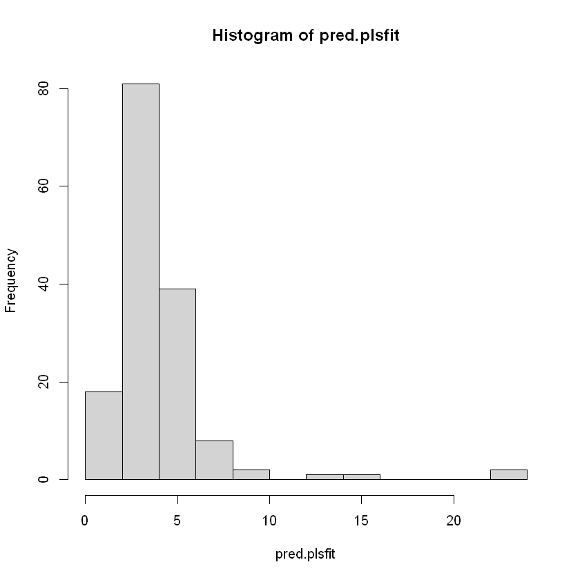

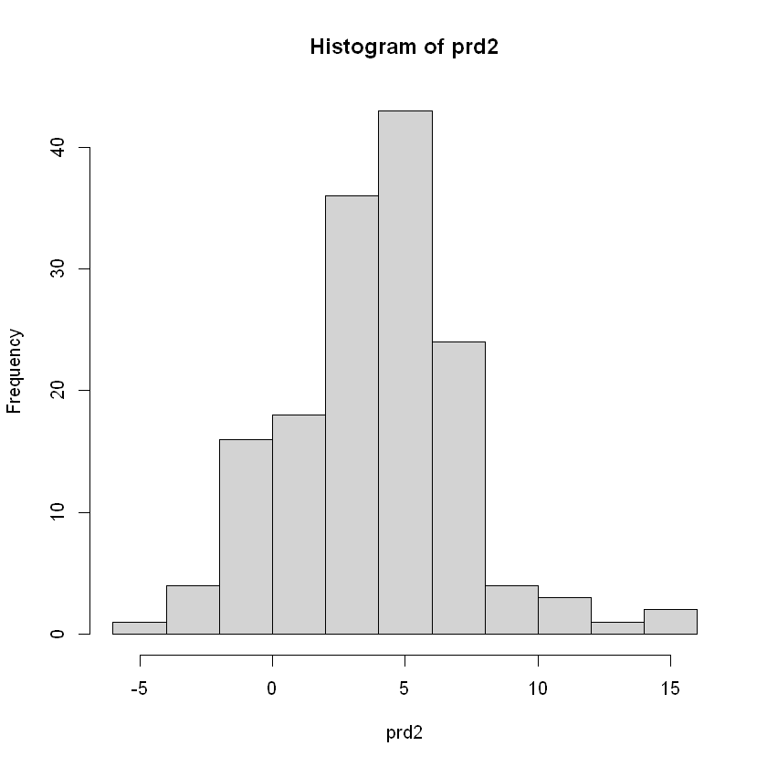

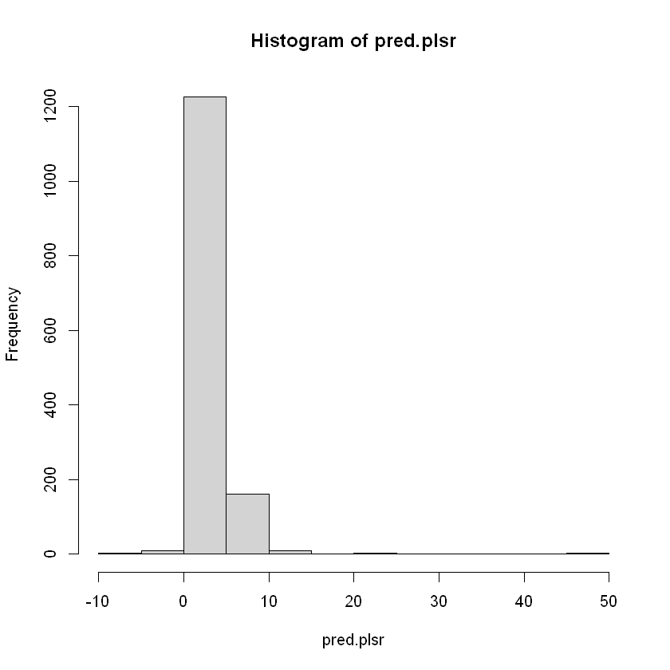

```r
p1 <- hist(pred.plsfit)
p2 <- hist(prd2)
p3 <- hist(pred.plsr)
```

## 8 . Conclusion

In the project, we have explored linear regression models from caret package. We also modelled a multiple linear regression model. We explored custom parameters such as Cross Validation.